# Assignment 1 - Suggested Answers

Firouz Fallahi

2024-05-31

Download and read the data set called insurance.csv into R and call it **df**. This data shows personal information and medical insurance cost charged for several individuals and has been used in Machine Learning with R by Brett Lantz. Next, install and load the *Tidyverse* package into R.

```r
# install.packages("tidyverse")
# if you want to install it again just remove  # from the beginning of the above line
library(tidyverse)
df <- read_csv("insurance.csv")
```

# 1

Create a histogram chart for the variable **charges** and color them **blue** and fill them in **red**.

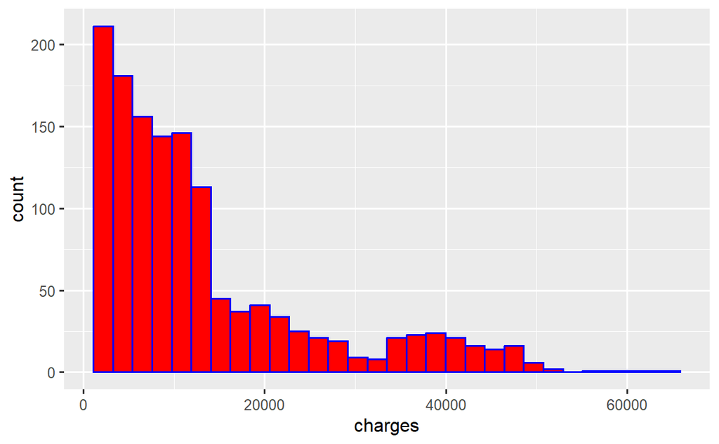

```r
ggplot(df) + geom_histogram( aes(x=charges), color='blue', fill='red')
```

# 2

Repeat the above plot again but instead of a histogram, create density plots and fill them according to the variable **Smoker** and also use the argument **alpha = 0.5** to make the densities transparent. Is there any differences between smokers and non-smokers? Hint: note that smoker is a variable included in the data set.

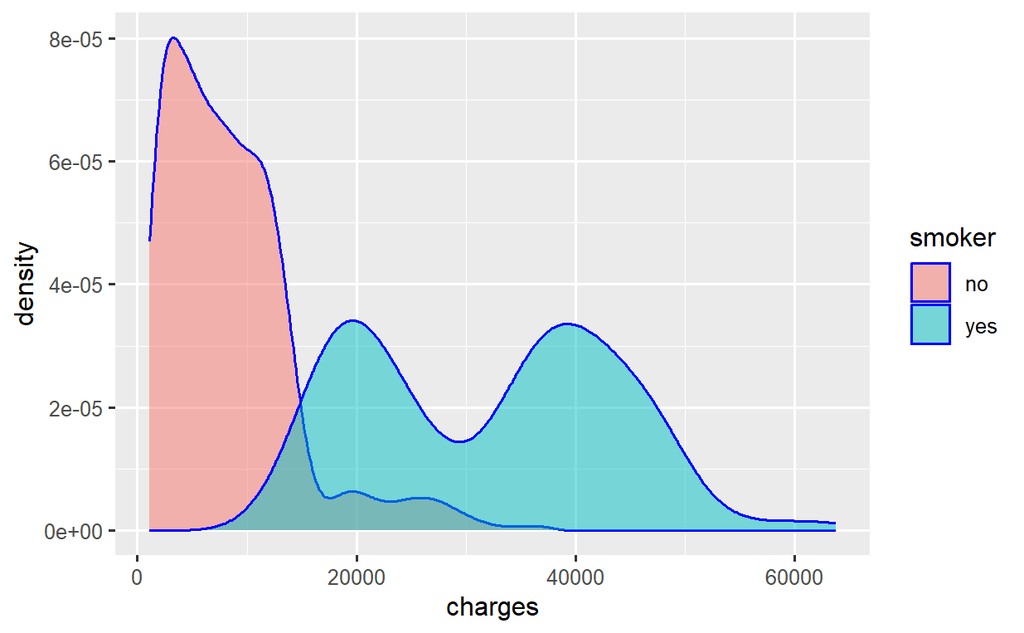

```r
ggplot(df) + geom_density(mapping = aes(x=charges , fill= smoker),
                          alpha =0.5,
                            color='blue')
```

This graph shows that in general those who do not smoke have been charged less compared to those who smoke. In addition, the curve for smokers is a bimodal distribution, which indicates that there are two types of smokers in terms of charges; the second group of smokers has much higher charges than the first group.

# 3

Is there any regional differences in density curves of charges among **smokers** and **non-smokers**? To show these differences create a graph and explain if you see any differences. (hint: you can use facet here).

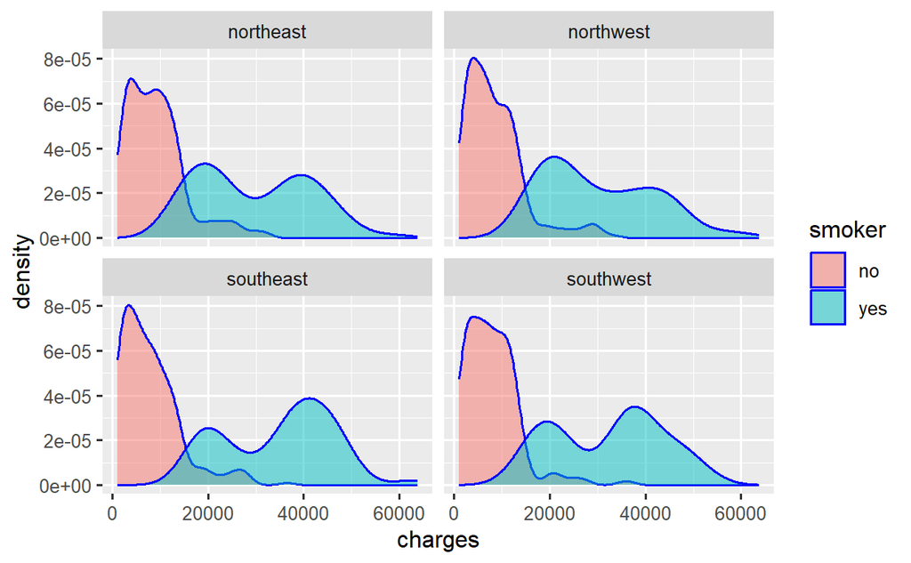

```r
ggplot(df) + geom_density(mapping = aes(x=charges , fill= smoker),
                          alpha =0.5,
                            color='blue') +
        facet_wrap(~region)
```

# 4

Install a package called **ggthemes** and load it into R. Next, create a boxplot chart for **Charges** and fill them based on **Smoker** and show the regional differences. Then, flip the axes and also change the theme to economist, which is included in the **ggtheme** package

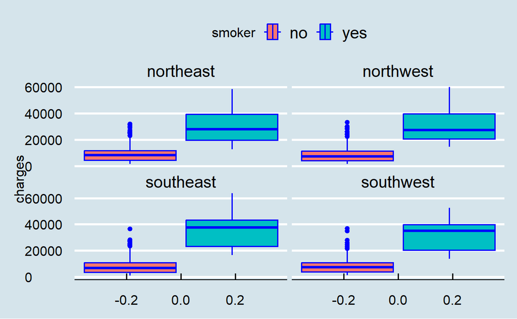

```r
library(ggthemes)
ggplot(df) + geom_boxplot(mapping = aes(x=charges , fill= smoker),
                          color='blue') +
        facet_wrap(~region) +
        coord_flip() +
        theme_economist()
```